# STSCI 4100: IDMb Analysis Project

## QUESTION 3:

Our third question is: **“Does having certain actors have an affect on ratings? Or is this just an effect of hiring good actors for good movies?”**

To answer this question, we’ll need to use the **principals** dataset because it contains actor information within the column **category**.

```r
# [1] Define a new DataFrame that's the same as principals, EXCEPT it only contains the rows that say "actor" and "actress."
unique(principals$category)
```

```
##  [1] "self"                "director"            "producer"
##  [4] "cinematographer"     "composer"            "writer"
##  [7] "editor"              "actor"               "actress"
## [10] "production_designer" "archive_footage"     "casting_director"
```

```r
actors.dataset <- principals[which(principals$category %in% c("actor", "actress")), ]

# [2] Merge the new DataFrame with my.dataset's "tconst" and "averageRating" column.
problem3 <- merge(actors.dataset,                                                            # New DataFrame we'll use for Problem 3
                  my.dataset[, c("tconst", "averageRating")],                                # 7 columns: same as principals, except with the column averageRating added.
                  by = "tconst")

dim(problem3)
```

```
## [1] 54555     7
```

- So why was there a reduction in the number of rows? It’s mainly because multiple rows within the principals dataset can tell information for the same, single movie.
- Unlike the main dataset my.dataset, we’re no longer dealing with one row for one movie.
- Consequently, not every row within the original principals dataset is meant for an actor — it can be meant for a director, composer, producer, etc.
- So if we only pull out the rows that contain “actor” or “actress,” then we are significantly dealing with only a subset of the principals dataset’s 200,000 rows.

In addition, the same film can have **more than one** actor. So in our new dataset **problem3**, we can see rows with repeated “nm000000” values, as those rows are discussing multiple actors within the same film.

Besides our new dataset **problem3**, there are **other caveats** to recognize:

1. The original principals dataset does not always specify an actor for every movie.
2. Some actors played relatively small roles such as “sneezing man.”
3. Worse, the principals dataset does not always even specify what role the actor played at all — we can’t tell if this is an actor with a big role or not.

The following is our analysis for question 3. Note that we will do a **similar** analysis for question 4 in terms of the steps taken.

```r
# [3] Compute each actor's number of films and average rating.
actors <- unique(problem3$nconst)                                                      # A vector of all unique actors; Each actor is identified w/ code like "nm0000000".
average.ratings <- numeric()                                                           # Initialize an empty vector — will contain each actor's average rating.
number.of.films <- numeric()                                                           # Initialize an empty vector — will contain each actor's number of films.

for (i in actors) {
  actor.indices <- which(problem3$nconst == i)                                         # A vector of the rows the actor appears in the dataset (the same one can appear in multiple).
  actor.ratings <- problem3$averageRating[actor.indices]                               # A vector of the actor's film ratings.

  average.ratings <- c(average.ratings, mean(actor.ratings, na.rm = TRUE))             # Computes the average of the actor's ratings.
  number.of.films <- c(number.of.films, length(actor.ratings))                         # Computes the number of times the actor appeared in.
}

actor.results <- data.frame(nconst = actors,                                           # A DataFrame of our results.
                            average.ratings = average.ratings,
                            number.of.films = number.of.films)
actor.results <- actor.results[order(actor.results$average.ratings, decreasing = TRUE), ]   # Reorganized DataFrame; top to bottom displays most to least film average ratings.

head(actor.results)                                                                         # Displaying the head of our DataFrame.
```

|  | nconst | average.ratings | number.of.films |
| --- | --- | --- | --- |
| 1112 | nm0367362 | 9 | 1 |
| 1296 | nm0712121 | 9 | 1 |
| 4593 | nm0187006 | 9 | 1 |
| 4594 | nm0696106 | 9 | 1 |
| 4595 | nm0861401 | 9 | 1 |
| 4629 | nm0376734 | 9 | 1 |

As we can see, when we rearranged our DataFrame to show us the actors who starred in films that got the highest to least average ratings, we ended up seeing actors who only starred in one film at the top. This tells us something important:

- Many actors who starred in films with high ratings (like 9/10) were actors who, **at least according to our dataset**, starred in only one film.
- That’s not that telling. Why? Here’s how we think of it: an actor who only starred in one film that got 10/10 reviews will obviously have an average film rating of 10/10.
- That clearly doesn’t say much in our analysis.
- On the other hand, an actor who starred in say 1000 films that all got 10/10 reviews will significantly mean more to our analysis.
- Yes, it could be true that if an actor starred in films that have an overall high rating, then the actor had some influence on the rating.
- However, if the actor has only appeared in one film (and that film has a high rating), then it’s harder to reach those same conclusions.

So, let’s see what happens if we focus on actors who starred in, say, at least 5 films.

```r
# [1] Filter the DataFrame to only have actors who starred in at least 5 films.
filtered.actor.results <- actor.results[actor.results$number.of.films >= 5, ]            # This is a new DataFrame.

# [2] Extract the top 10 actors — they are within the first 10 rows.
filtered.actor.results[1:10,]                                                            # Extract the first 10 rows.
```

|  | nconst | average.ratings | number.of.films |
| --- | --- | --- | --- |
| 5290 | nm0246262 | 7.980000 | 5 |
| 9496 | nm0297054 | 7.540000 | 5 |
| 1111 | nm0000858 | 7.469231 | 26 |
| 1109 | nm0381936 | 7.383333 | 6 |
| 1411 | nm0206750 | 7.340000 | 5 |
| 5028 | nm0444172 | 7.300000 | 15 |
| 5071 | nm0348162 | 7.300000 | 5 |
| 1176 | nm0096737 | 7.280000 | 5 |
| 11521 | nm0375609 | 7.233333 | 9 |
| 3588 | nm0378548 | 7.228571 | 7 |

Now let’s check out the actors with a Google search.

- He starred in 36 films, not six.
- Based on only six films, his films’ average rating is 7.383333 out of 10.
- The fact that the given dataset does not accurately tell us the correct number of films he had in his career is one thing.
- But the fact that the number of films he starred in was only six — and he was not a child actor who passed young — in this dataset is still considerably small.

So, let’s see what happens if we focus on actors who starred in, say, at least 20 films (this is larger than 5 films).

```r
# [1] Filter the DataFrame to only have actors who starred in at least 20 films.
filtered.actor.results2 <- actor.results[actor.results$number.of.films >= 20, ]            # This is a new DataFrame.

# [2] Extract the top 10 actors — they are within the first 10 rows.
filtered.actor.results2[1:10,]                                                            # Extract the first 10 rows.
```

|  | nconst | average.ratings | number.of.films |
| --- | --- | --- | --- |
| 1111 | nm0000858 | 7.469231 | 26 |
| 7204 | nm0731247 | 7.155000 | 20 |
| 3495 | nm0074788 | 7.137931 | 29 |
| 1292 | nm0324553 | 7.054167 | 24 |
| 4035 | nm0042317 | 7.048148 | 27 |
| 319 | nm0832458 | 6.921429 | 28 |
| 5477 | nm0203836 | 6.885294 | 34 |
| 4984 | nm0000036 | 6.863636 | 55 |
| 3572 | nm0579663 | 6.834286 | 35 |
| 5077 | nm0000509 | 6.804762 | 21 |

Here, the first actor “nm0000858” is **John Barrymore** (1882-1942).

What’s the point we’re trying to get to?

1. The number of films in our dataset are not entirely accurate — many are smaller than they are because of **lost records** and poor documentation (most are early 1900’s films).
2. The inaccurate number of films affects what their computed average ratings are.
3. Therefore, it’s possible that there are actors within our dataset who may have either higher or lower final average ratings than our computations suggest.

Here’s one last case to look at:

```r
maximum.films <- max(number.of.films)
indices <- which(actor.results$number.of.films == maximum.films)

c(actor.results$nconst[indices[1]], actor.results$nconst[indices[2]])
```

```
## [1] "nm0115524" NA
```

```r
c(actor.results$average.ratings[indices[1]], actor.results$average.ratings[indices[2]])
```

```
## [1] 5.699419       NA
```

This clearly reinforces our point earlier about sample size — comparing smaller actors who have less films with higher final average ratings against larger actors who have more films with smaller final average ratings doesn’t seem to make sense.

In short, it’s **hard** to identify a pattern and see if having certain actors have an affect on ratings due to data incompleteness. We **can’t confuse causation with correlation**, but it’s hard to **find a pattern** when some actors should have a larger associated number of films, and when those who do have lots of films end up with lower ratings.

As a final summary, here is a plot that visualizes the cases we’ve seen:

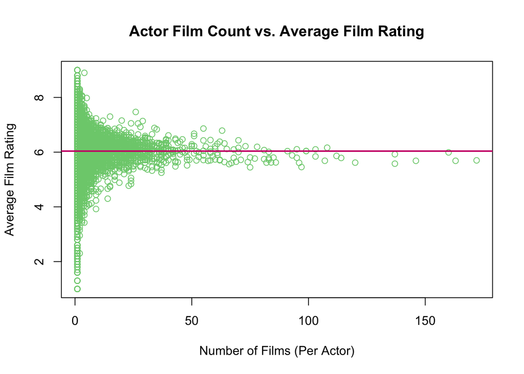

```r
plot(actor.results$number.of.films,
     actor.results$average.ratings,
     main = "Actor Film Count vs. Average Film Rating",
     xlab = "Number of Films (Per Actor)",
     ylab = "Average Film Rating",
     col = "palegreen3")
abline(h = mean(problem3$averageRating), col = "deeppink3", lwd = 2)
```

## QUESTION 4:

Lastly, we’ll finally ask: **which genres get the highest ratings?**

```r
# [1] Define our variables.
unique.length <- length(unique(my.dataset$genres))                               # Defines the length of the unique entries in the column "genres."
#anyNA(my.dataset$genres)                                                        # Remember there are missing values in the column "genres."

list.of.genres <- list()                                                         # Instantiates an empty list.
for (i in 1:unique.length){                                                      # Uses a for-loop to update the empty list.
  extracted.vector <- strsplit(unique(my.dataset$genres)[i], split = ",")[[1]]
  list.of.genres[[i]] <- extracted.vector                                        # Here, list.of.genres is a list of all the genres, each entry being a vector.
}                                                                                # ex: The character "Documentary, Short" will turn into the vector ("Documentary, "Short")

vector.of.genres <- unlist(list.of.genres)                                       # Unpacks a list list.of.genres into a vector; the vector's consequently longer than the list.
pure.genres <- unique(vector.of.genres)                                          # Defines a vector pure.genres that lists all the PURE genres in the entire dataset; much shorter.

# [2] Remove the entries NA and "Short". Those are NOT genres.
pure.genres <- pure.genres[!pure.genres %in% c("Short", NA)]                     # These are all the official genres our dataset uses.
```

For this analysis, we will **assume** that we’re working with **pure genres**.

- We have defined a vector **pure.genres** that contains all 27 unique, pure genres in our dataset.
- A **pure** genre is the opposite of a combined genre. For instance, our vector’s entries say words such as “Action” or “Comedy” rather than something such as “Action Comedy.”

It’s important to note that our vector **pure.genres** does not include the words “Short” and NA:

- Long story short: NA is a missing value, while “Short” is not a genre. (It’s a format.)
- In addition, when you quickly look at the column “genres” within our dataset, you will briefly see plenty of rows that contain a genre that says “Short” (and nothing more).
- This is clearly not helpful, as it tells us nothing about what the genre of the film was.
- So for our analysis, we made the decision to **ignore** films whose corresponding genre says just “Short” or NA.

```r
# Checking how many rows (i.e. films) just say "Short" and NA:
number.of.shorts <- length(which(my.dataset[,9] == "Short"))               # Number of rows in dataset that just say "Short."
number.of.NA <- sum(is.na(my.dataset[,9]))                                 # Number of rows in dataset that have missing values.

# Here are the proportions, where the total number of rows is 139602:
number.of.shorts / 139602                                                  # Proportion of "Short" rows.
number.of.NA / 139602                                                      # Proportion of missing value rows.
(number.of.shorts + number.of.NA) / 139602                                 # Proportion of both "Short" and missing value rows.
```

[output not shown]

As we can see, there are 2529 rows that just say “Short” and 4442 rows that contain missing values, making up 1.8% and 3.1% of the dataset’s total rows. In total, they make up around 5% of the dataset’s total rows.

- That is **really, really small**.
- So, we’ll proceed to ignore those “Short” and missing value rows for our analysis.

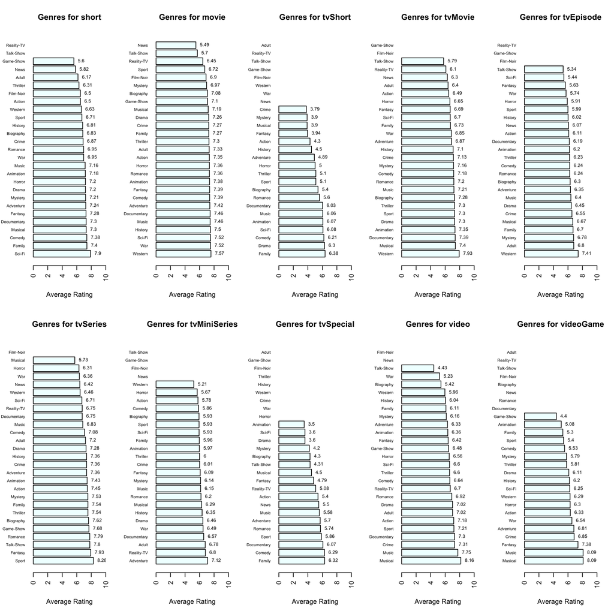

```r
par(mfrow = c(2, 5))

for (i in unique(my.dataset$titleType)){                                          # [1] For each kind of film, compute the average ratings for its pure genres.
  number.of.ratings <- c()                                                        # Initialize empty vector — to contain number of ratings found for each pure genre.
  average.ratings <- c()                                                          # Initialize empty vector — to contain weighted average ratings for each pure genre.
  movie.indices <- which(my.dataset$titleType == i)

  for (j in pure.genres){                                                         # Update both empty vectors.
    indices <- which(grepl(j, my.dataset$genres[movie.indices]))
    how.many.ratings <- length(indices)

    ratings <- my.dataset$averageRating[indices]
    number.of.votes <- my.dataset$numVotes[indices]
    weighted.average <- sum(ratings * number.of.votes) / sum(number.of.votes)

    average.ratings <- append(average.ratings, weighted.average)
    number.of.ratings <- append(number.of.ratings, how.many.ratings)
  }

  ratings.df <- data.frame(genre = pure.genres,                                   # [2] Make a barplot comparing the average ratings for each pure genre.
                           number = number.of.ratings,
                           average = average.ratings)
  ratings.df <- ratings.df[order(ratings.df$average, decreasing = TRUE), ]

  my.barplot <- barplot(ratings.df$average, main = paste("Genres for", i),
          names.arg = ratings.df$genre,
          xlab = "Average Rating",
          las = 2,
          col = "azure1",
          cex.names = 0.6,
          horiz = TRUE,
          xlim = c(0, 10))

  text(x = ratings.df$average,
       y = my.barplot,
       labels = round(ratings.df$average, 2),
       pos = 4,
       cex = 0.7,
       col = "black")
}
```

Here is what we should take away from the plot.

In addition, we computed a **weighted average** rating for each genre. + This is crucial because upon looking at the column **numVotes**, we can see that not every film has had the same number of votes. + In other words, not every film has had the same number of reviewers. + The number of votes clearly influences how each genre’s computed average rating will turn out. + By computing a weighted average, we are giving less influence to small genres that have skewed/inflated ratings and more influence to larger genres.

Before, we simply calculated a regular **average** using the mean() function, which incorrectly acts as if all films have received the same number of votes.

- Consequently, we get bizarre results.
- For instance, three of our box plots suggested that adult genres have been the most highly rated genres for tvMovies, tvSeries, and tvMiniSeries.

Here are two observations we made:

```r
# [1] Check if any sample sizes (used to compute each pure genre's average) were small.
any(ratings.df$number < 50)
```

```
## [1] TRUE
```

```r
min(ratings.df$number)
```

```
## [1] 0
```

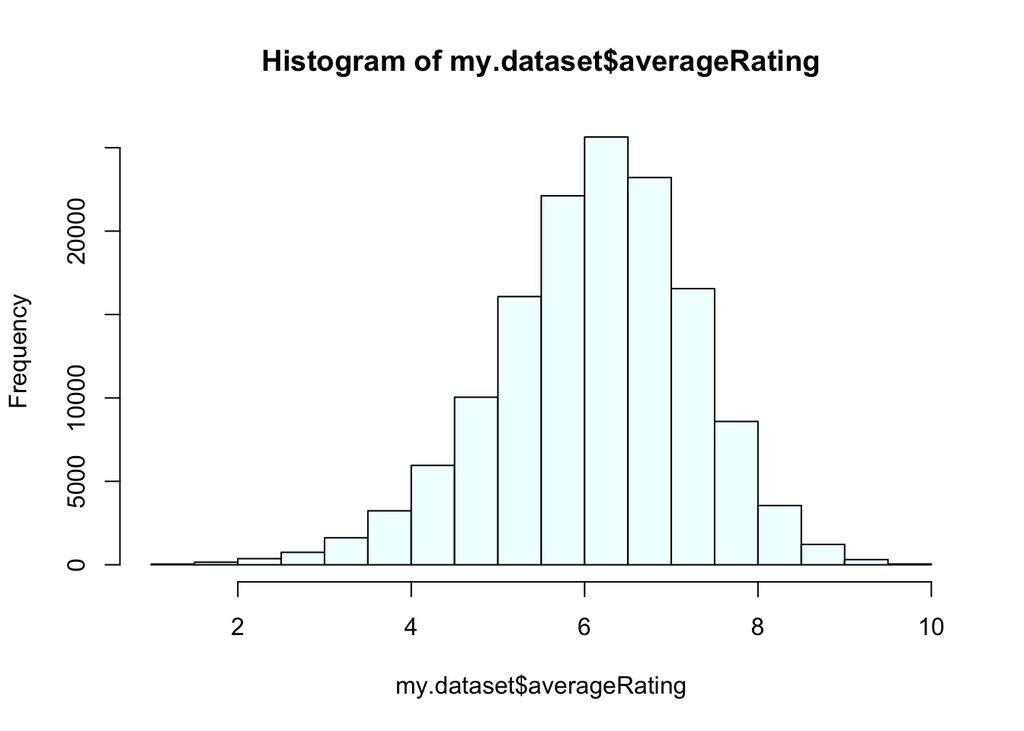

```r
# [2] Check the distribution of the averageRating column from our dataset.
hist(my.dataset$averageRating, col = "azure1")
```

```r
summary(my.dataset$averageRating)
```

```
##    Min. 1st Qu.  Median    Mean 3rd Qu.    Max.
##   1.000   5.500   6.200   6.157   6.900  10.000
```

Some other external notes:

- One factor that **could** lead to a change in results is the fact that we had to omit films whose specified genres either said “Short” or “genre.” If we knew what the genres of those films actually were, then their contribution could change the outcome of our computed weighted averages.
- In addition, the average ratings don’t necessarily determine what’s more popular — it’s **also** important to consider other factors such as total box office revenue.

# [4] SUMMARY:

In short, we have learned a lot about our datasets from these four questions. However, these analyses don’t cover absolutely everything we can learn from them.

If time permits, we can look further into:

1. Comparing movies over the years — movies from the early 19th Century to movies today.
2. Looking to see if there are any more open-source, updated datasets with all actors’ films recorded.
3. Considering total box office revenue as part of a larger goal to better understand what factors dictate the success of a movie.
4. Looking into questions for **specific** kinds of film — investigate trends only within movies, or shorts, and so on rather than a whole dataset that deals with a blend of them all.

Overall, this project was a good exercise that blends **technical statistical** knowledge with **real circumstance**. Understanding statistical theory is important, but understanding when and how it should be used is just as, if not more, important.